# Insights & Planning Business Partner, Platform Project Brief

rysu@

2022-05-08

### Part 1: Headcount, Budget, & KPIs

The below are notes only. Please view the [executive presentation here](https://docs.google.com/presentation/d/1QH9XXmQfseEqFuD7kOtm9nAyvmIeToPjPU8kpSbgFJ8/edit?usp=sharing). Additional calculations I made in the data worksheet are [available here](https://docs.google.com/spreadsheets/d/1zcNPdhVsWFsQT9hQo9NdoY4ZFR0iL9zNDqsMriaPS04/edit?usp=sharing).

#### 1. *Levers: what are the biggest levers for improving User Experience and Operations Efficiency?*

**User Experience**: UX can be measured by transactional CSAT (as provided in the spreadsheet), overall CSAT (obtained through periodic surveys), and many other metrics. These could include support cases per user annually, product and feature utilization, and crash or service fault frequency.

Transactional CSAT and cases per user are available in the provided data. CSAT is the UX KPI for working with our staff/subsidiary/vendor, while cases per user is a proxy for product-level UX. CSAT has been strong, but cases per user have been increasing.

Cases solved by our stripes attain the highest CSAT among channels, so **shifting more budget to hiring FTEs is one way we could further drive CSAT**. However, FTEs solving cases is becoming increasingly costly (est. $183/case in 2022, [row 21](https://docs.google.com/spreadsheets/d/1zcNPdhVsWFsQT9hQo9NdoY4ZFR0iL9zNDqsMriaPS04/edit#gid=0&range=H21)), so investing instead into the vendor team (low cost for strong CSAT) may be a more effective strategy.

Investigating the nature of support cases may be useful as well to address the rising case/user count. Reducing this number through product improvements or self-help resources would be beneficial to UX and would control operational support costs.

**Operational Efficiency**: Operational efficiency can be measured by [cost per case](https://docs.google.com/spreadsheets/d/1zcNPdhVsWFsQT9hQo9NdoY4ZFR0iL9zNDqsMriaPS04/edit#gid=0&range=B49) across channels as well as revenue supported per Support Ops FTE. Other metrics not available in the data provided could be average case resolution time, average number of messages until resolution, or utilization rates of self-help resources.

To improve operational efficiency, Stripe should shift more cases to vendors, since the cost per case is much lower than other channels (est. $11 in 2022) while still delivering strong CSAT. This shift already started in 2021 and should keep cost per case at a reasonable level.

I would also reassess the support ops FTE recruitment planned in 2022 (179 to 419 FTE). Support cases directed to stripes is expected to increase by 43%, but hiring is accelerating by 138%. This could be for top tier client support or some other initiative, but is a costly investment in terms of operational efficiency.

#### 2. *What key performance indicators (KPIs) would you use to track performance (max. 4)?*

Operations has two key strategic goals - to continuously improve the user experience, while also improving the operating efficiency. I would track the below metrics to be able to measure success in meeting these goals.

- **Cost per case**: This metric should be measured to control operational costs and direct budgeting for case handling. As we can see with the data, using the vendor team looks like an efficient way to solve cases while maintaining strong CSAT.
- **Total resolution time**: Tracking resolution time is an important measure of complexity of cases and support staff’s ability to resolve them in an effective manner. An increase here could be a leading indicator of declining CSAT.
- **CSAT**: Keeping an eye on CSAT is always important to ensure users are happy. Happy users continue using the product and speak highly of it to their colleagues as well.
- **Cases per user**: In order to sustainably grow the userbase, this number should remain stable or ideally decrease. An increasing trend here would imply increasing support costs to sustain the growth in users. To reduce it, there should be an analysis on the nature of the cases and a plan on how to address those issues. Building and promoting self-help resources and training programs would also assist this at scale.

### Part 2: Conversion Analysis

The provided `crts.csv` file is a list of aggregated visit and conversion data by week (20 weeks), browser, and country.

#### i. *What is the weekly conversion rate across all countries and browsers over time? Is there anything interesting about the trend?*

The chart below shows visits and conversions in millions for the provided data set, as well as the conversion rate in the right hand panel. Both visits and conversions rise steadily at similar rates, and both see a jump in week 7.

The **conversion rate** starts off declining until week 6, before jumping to over `0.40` in week 7. In the following weeks, it continues to decline again at a similar rate. This is quite a high conversion rate in general, and the jump in week 7 is surprising. Depending on the nature of the site, there could have been a sale, promotion, or some other catalyst that week that drove both visits and conversions.

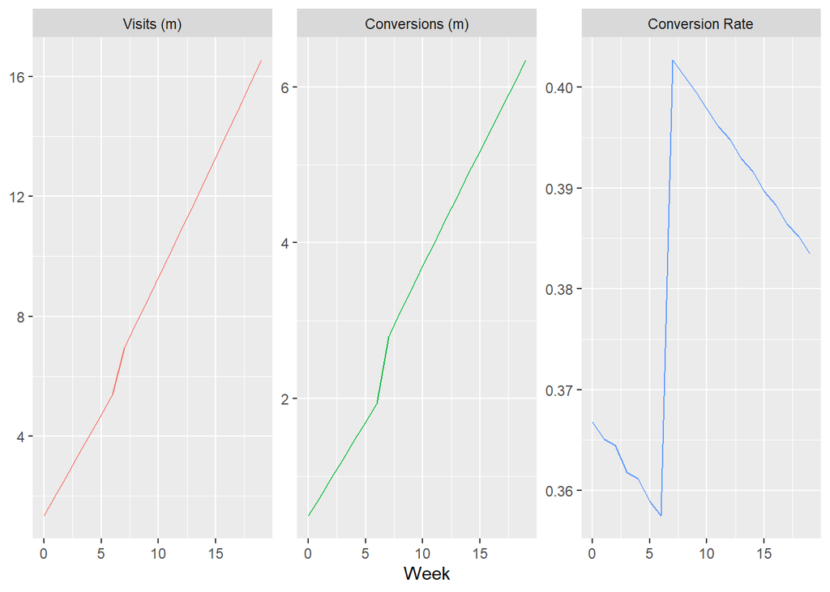

#### ii. *How can you explain your finding(s) from the aggregated longitudinal data?*

Looking at the data across browsers, the jump in week 7 is apparent in each browser. Traffic levels and conversion rate performance are different, but the event in week 7 is broad-based.

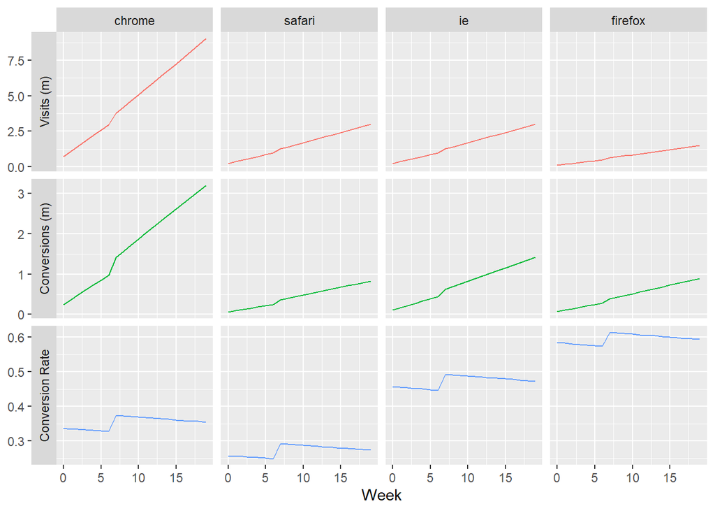

Looking across countries, we see that the week 7 event occurred in **AC**. All other countries’ visits and conversions are generally linear. Since **AC** is also the 2nd largest country by visits volume, this sudden jump in traffic shifted the overall conversion rate towards **AC**’s conversion rate (which is high).

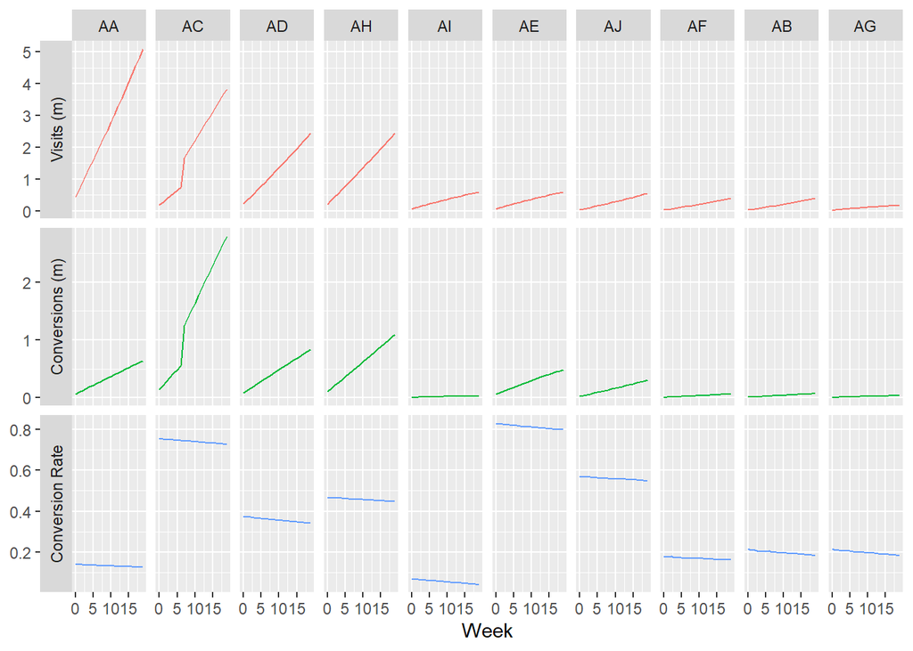

Looking at the metrics across browsers in **AC**, we see **chrome** is the largest browser for traffic and conversions by far. **ie** and **firefox** are much smaller but have exceptional conversion rates. The conversion rate is so high in those browsers that there could be some fraud or something peculiar going on.

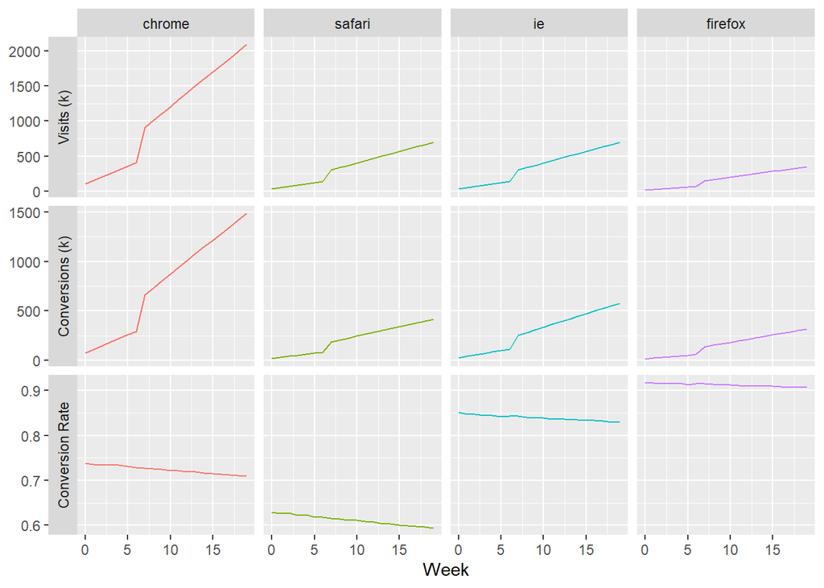

#### iii. *What is your hypothesis on why the global conversion rate increased?*

In week 7 there was some event or promotion that drove an increase in traffic and conversions in country **AC**. The global conversion rate jumped due to **AC** becoming a major global source of traffic for the website. **AC**’s conversion rate is consistently over `0.70`.

#### iv. *[SQL] What are the total visits by browser?*

The `tidyquery` package runs SQL within R on a data frame.

```r
query(
'  SELECT browser, sum(visits) as totalVisits
   FROM data
   GROUP BY browser
   ORDER BY totalVisits DESC;'
)
```

```
## # A tibble: 4 x 2
##   browser totalVisits
##   <fct>         <dbl>
## 1 chrome     95825265
## 2 safari     31950053
## 3 ie         31937898
## 4 firefox    15969172
```

#### v. *[SQL] Rank each country based on their conversion rate performance for each week.*

I’m a little unclear on the expected output for this one, but here is the conversion rate in ranked order of countries per week.

```r
query(
'  SELECT week, country, sum(conversions)/sum(visits) as conversionRate
   FROM data
   GROUP BY week, country
   ORDER BY week, conversionRate DESC;'
)
```

```
## # A tibble: 200 x 3
##     week country conversionRate
##    <dbl> <chr>            <dbl>
##  1     0 AE              0.830
##  2     0 AC              0.755
##  3     0 AJ              0.568
##  4     0 AH              0.464
##  5     0 AD              0.374
##  6     0 AG              0.214
##  7     0 AB              0.214
##  8     0 AF              0.176
##  9     0 AA              0.140
## 10     0 AI              0.0674
## # ... with 190 more rows
```